# Project Four

### In this project we'll explore about the deaths, Active, Recovered people from covid

### We can answer some questions about this dataset

## First question: What's country that has the largest number of deaths?

## Second question: What's country that has largest number recovered from covid?

## Third quetion : How is the change of the death over months?

#### Let's Start our journey

```python
import numpy as np
import pandas as pd
import matplotlib.pyplot as plt
%matplotlib inline
```

```python
df =pd.read_csv('covid19.csv')
df.head()
```

|  | Province/State | Country/Region | Lat | Long | Date | Confirmed | Deaths | Recovered | Active | WHO Region |
| --- | --- | --- | --- | --- | --- | --- | --- | --- | --- | --- |
| 0 | NaN | Afghanistan | 33.93911 | 67.709953 | 2020-01-22 | 0 | 0 | 0 | 0 | Eastern Mediterranean |
| 1 | NaN | Albania | 41.15330 | 20.168300 | 2020-01-22 | 0 | 0 | 0 | 0 | Europe |
| 2 | NaN | Algeria | 28.03390 | 1.659600 | 2020-01-22 | 0 | 0 | 0 | 0 | Africa |
| 3 | NaN | Andorra | 42.50630 | 1.521800 | 2020-01-22 | 0 | 0 | 0 | 0 | Europe |
| 4 | NaN | Angola | -11.20270 | 17.873900 | 2020-01-22 | 0 | 0 | 0 | 0 | Africa |

```python
df.info()
```

```
<class 'pandas.core.frame.DataFrame'>
RangeIndex: 49068 entries, 0 to 49067
Data columns (total 10 columns):
 #   Column          Non-Null Count  Dtype
---  ------          --------------  -----
 0   Province/State  14664 non-null  object
 1   Country/Region  49068 non-null  object
 2   Lat             49068 non-null  float64
 3   Long            49068 non-null  float64
 4   Date            49068 non-null  object
 5   Confirmed       49068 non-null  int64
 6   Deaths          49068 non-null  int64
 7   Recovered       49068 non-null  int64
 8   Active          49068 non-null  int64
 9   WHO Region      49068 non-null  object
dtypes: float64(2), int64(4), object(4)
memory usage: 3.7+ MB
```

#### In the row called 'Province/State ' there're null numbers

```python
df.describe()
```

|  | Lat | Long | Confirmed | Deaths | Recovered | Active |
| --- | --- | --- | --- | --- | --- | --- |
| count | 49068.000000 | 49068.000000 | 4.906800e+04 | 49068.000000 | 4.906800e+04 | 4.906800e+04 |
| mean | 21.433730 | 23.528236 | 1.688490e+04 | 884.179160 | 7.915713e+03 | 8.085012e+03 |
| std | 24.950320 | 70.442740 | 1.273002e+05 | 6313.584411 | 5.480092e+04 | 7.625890e+04 |
| min | -51.796300 | -135.000000 | 0.000000e+00 | 0.000000 | 0.000000e+00 | -1.400000e+01 |
| 25% | 7.873054 | -15.310100 | 4.000000e+00 | 0.000000 | 0.000000e+00 | 0.000000e+00 |
| 50% | 23.634500 | 21.745300 | 1.680000e+02 | 2.000000 | 2.900000e+01 | 2.600000e+01 |
| 75% | 41.204380 | 80.771797 | 1.518250e+03 | 30.000000 | 6.660000e+02 | 6.060000e+02 |
| max | 71.706900 | 178.065000 | 4.290259e+06 | 148011.000000 | 1.846641e+06 | 2.816444e+06 |

```python
df.rename(columns = lambda x : x.strip().lower().replace(" ","_"), inplace = True)
df.head()
```

|  | province/state | country/region | lat | long | date | confirmed | deaths | recovered | active | who_region |
| --- | --- | --- | --- | --- | --- | --- | --- | --- | --- | --- |
| 0 | NaN | Afghanistan | 33.93911 | 67.709953 | 2020-01-22 | 0 | 0 | 0 | 0 | Eastern Mediterranean |
| 1 | NaN | Albania | 41.15330 | 20.168300 | 2020-01-22 | 0 | 0 | 0 | 0 | Europe |
| 2 | NaN | Algeria | 28.03390 | 1.659600 | 2020-01-22 | 0 | 0 | 0 | 0 | Africa |
| 3 | NaN | Andorra | 42.50630 | 1.521800 | 2020-01-22 | 0 | 0 | 0 | 0 | Europe |
| 4 | NaN | Angola | -11.20270 | 17.873900 | 2020-01-22 | 0 | 0 | 0 | 0 | Africa |

```python
df.drop(['province/state', 'lat', 'long'], axis =1, inplace = True)
df.head()
```

|  | country/region | date | confirmed | deaths | recovered | active | who_region |
| --- | --- | --- | --- | --- | --- | --- | --- |
| 0 | Afghanistan | 2020-01-22 | 0 | 0 | 0 | 0 | Eastern Mediterranean |
| 1 | Albania | 2020-01-22 | 0 | 0 | 0 | 0 | Europe |
| 2 | Algeria | 2020-01-22 | 0 | 0 | 0 | 0 | Africa |
| 3 | Andorra | 2020-01-22 | 0 | 0 | 0 | 0 | Europe |
| 4 | Angola | 2020-01-22 | 0 | 0 | 0 | 0 | Africa |

#### We can see that we don't need some columns that is unuseful for us to answer our questions

```python
df.isnull().sum()
```

```
country/region    0
date              0
confirmed         0
deaths            0
recovered         0
active            0
who_region        0
dtype: int64
```

#### Now we don't have null values

#### Let's answer our questions

## First question: What's country that has the largest number of deaths?

```python
most_death = df.query('deaths == 148011')
most_death
```

|  | country/region | date | confirmed | deaths | recovered | active | who_region |
| --- | --- | --- | --- | --- | --- | --- | --- |
| 49030 | US | 2020-07-27 | 4290259 | 148011 | 1325804 | 2816444 | Americas |

### The largest number of deaths in US about 148011 at 27 july 2020

## Second question: What's country that has largest number recovered from covid?

```python
df[df['recovered'] == df['recovered'].max()]
```

|  | country/region | date | confirmed | deaths | recovered | active | who_region |
| --- | --- | --- | --- | --- | --- | --- | --- |
| 48835 | Brazil | 2020-07-27 | 2442375 | 87618 | 1846641 | 508116 | Americas |

### The largest number recovered from covid is in Brazil about 1846641 at 27 july 2020

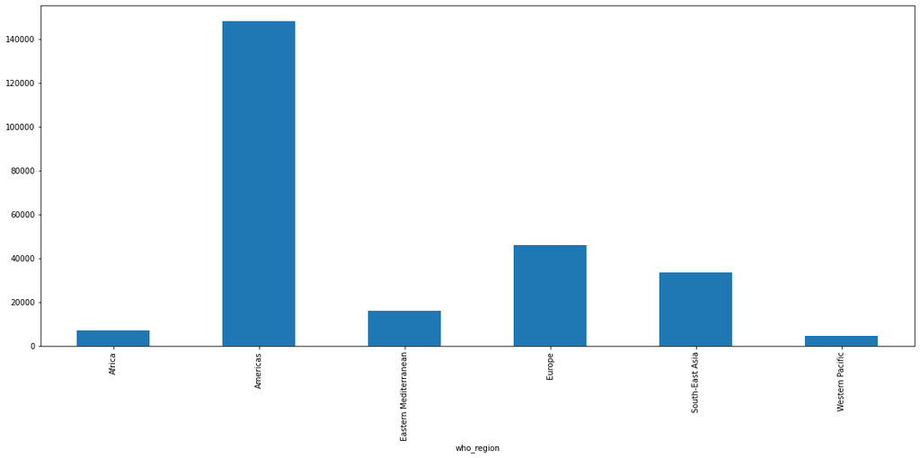

```python
plt.figure(figsize =(20,8))
most_region_deaths = df.groupby('who_region')['deaths'].max().plot(kind = 'bar')
plt.show()
```

```python
most_region_recovered = df.groupby('who_region')['recovered'].max()
most_region_recovered
```

```
who_region
Africa                    274925
Americas                 1846641
Eastern Mediterranean     255144
Europe                    602249
South-East Asia           951166
Western Pacific            64435
Name: recovered, dtype: int64
```

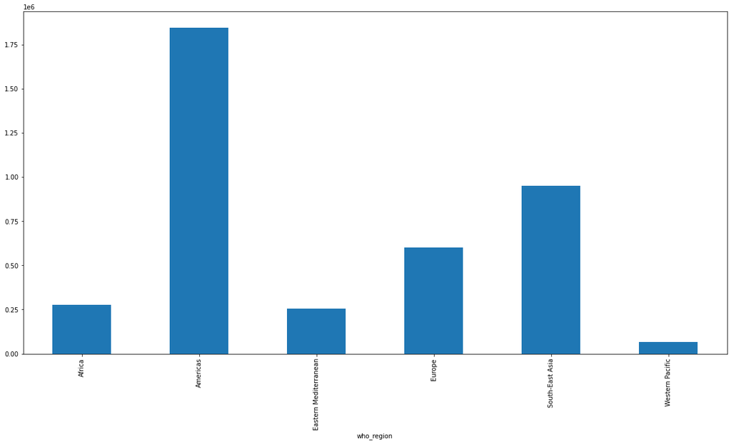

```python
plt.figure(figsize = (20,10))
most_region_recovered.plot(kind = 'bar')
plt.show()
```

## Third quetion : How is the change of the death over months?

```python
df['Months'] = df['date'].str.split('-').str[1].astype(int)
df.head()
```

|  | country/region | date | confirmed | deaths | recovered | active | who_region | Months |
| --- | --- | --- | --- | --- | --- | --- | --- | --- |
| 0 | Afghanistan | 2020-01-22 | 0 | 0 | 0 | 0 | Eastern Mediterranean | 1 |
| 1 | Albania | 2020-01-22 | 0 | 0 | 0 | 0 | Europe | 1 |
| 2 | Algeria | 2020-01-22 | 0 | 0 | 0 | 0 | Africa | 1 |
| 3 | Andorra | 2020-01-22 | 0 | 0 | 0 | 0 | Europe | 1 |
| 4 | Angola | 2020-01-22 | 0 | 0 | 0 | 0 | Africa | 1 |

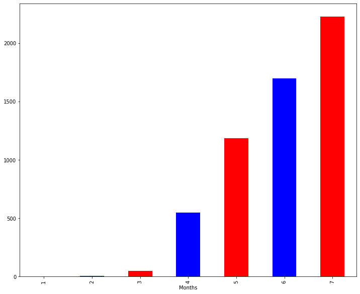

```python
plt.figure(figsize = [12,10])
df.groupby('Months')['deaths'].mean().plot(kind = 'bar', color = ['red','blue'])
plt.show();
```

### We can see that the average of deaths increases as the months increasing

### We can provide some additional information

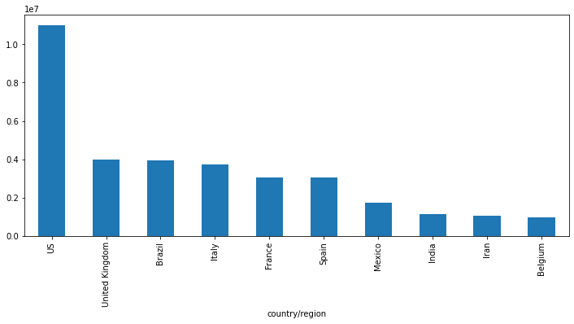

```python
plt.figure(figsize = [12,5])
df.groupby('country/region')['deaths'].sum().sort_values(ascending = False).head(10).plot(kind ='bar')
plt.show();
```

### Here we can see the the Top 10 countries according to deaths cases

```python
df.groupby('date')[['deaths', 'confirmed', 'active', 'recovered']].sum().reset_index()
```

|  | date | deaths | confirmed | active | recovered |
| --- | --- | --- | --- | --- | --- |
| 0 | 2020-01-22 | 17 | 555 | 510 | 28 |
| 1 | 2020-01-23 | 18 | 654 | 606 | 30 |
| 2 | 2020-01-24 | 26 | 941 | 879 | 36 |
| 3 | 2020-01-25 | 42 | 1434 | 1353 | 39 |
| 4 | 2020-01-26 | 56 | 2118 | 2010 | 52 |
| ... | ... | ... | ... | ... | ... |
| 183 | 2020-07-23 | 633506 | 15510481 | 6166006 | 8710969 |
| 184 | 2020-07-24 | 639650 | 15791645 | 6212290 | 8939705 |
| 185 | 2020-07-25 | 644517 | 16047190 | 6243930 | 9158743 |
| 186 | 2020-07-26 | 648621 | 16251796 | 6309711 | 9293464 |
| 187 | 2020-07-27 | 654036 | 16480485 | 6358362 | 9468087 |

188 rows × 5 columns

```python
covidInfo = df.groupby('country/region')['deaths'].sum().sort_values(ascending = False).reset_index().head()
covidInfo
```

|  | country/region | deaths |
| --- | --- | --- |
| 0 | US | 11011411 |
| 1 | United Kingdom | 3997775 |
| 2 | Brazil | 3938034 |
| 3 | Italy | 3707717 |
| 4 | France | 3048524 |

### The top 5 countries with the number of deaths

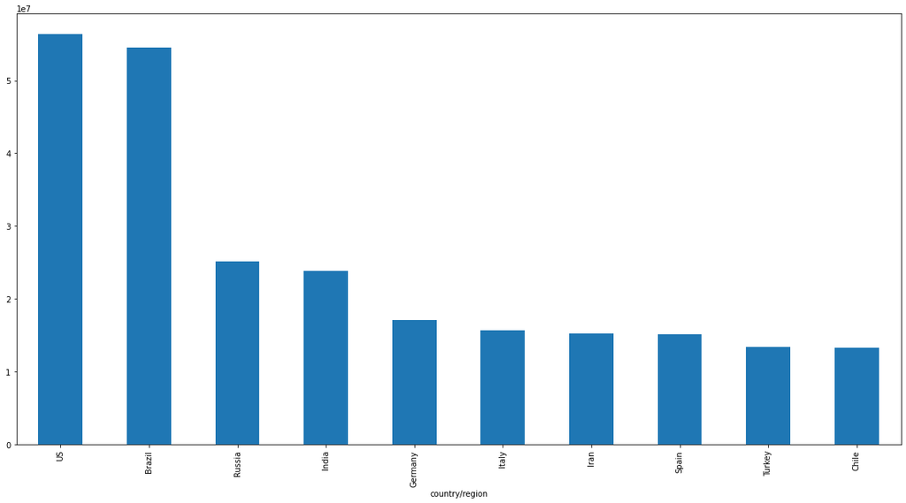

```python
plt.figure( figsize = (20,10))
df.groupby('country/region')['recovered'].sum().sort_values(ascending = False).head(10).plot(kind ='bar')
plt.show();
```

### We can see that US and brazil have competition but US is the in top of the recovering

```python
df.groupby('country/region')['recovered'].sum().sort_values(ascending = False).reset_index().head()
```

|  | country/region | recovered |
| --- | --- | --- |
| 0 | US | 56353416 |
| 1 | Brazil | 54492873 |
| 2 | Russia | 25120448 |
| 3 | India | 23783720 |
| 4 | Germany | 17107839 |

# Conculsion:

### US is the country that recorded largest number of deaths at 27 july 2020 about 148011 deaths

### Brazil is the country that recorded largest number of recovered at 27 july 2020 about 1846641

### as increasing the days and months ,The recoding of deaths incrases

### The top countries that recoreded deaths as total is US and United Kingdom

### The top countries that recoreded recovered cases as total is US and Brazil

### US is the most country that is affected by covid 19 and that led to loses weather souls of people and the economy of the country